# Avaliação I

Avaliação I (Estatística) 04/04/2021

[figure not shown]

## Informações Relevantes

Usaremos algumas bases de dados reais para realização dessa prova. Por conta disso, o tempo de resolução será extendido, visto que algumas dessas bases possuem mais de 50 MB, o que pode ocasionar demora no *download*.

As bases de dados serão retiradas de nosso repositório do GitHub e do *site* brasil.io.

Faça o *download* dos seguintes conjuntos de dados:

1. [Salário de Magistrados](https://drive.google.com/file/d/1FCdmXKf35dTtmnZQ1XhQPl7sF1MxX7WV/view?usp=sharing);
2. [Cursos e notas de corte do PROUNI 2018](https://drive.google.com/file/d/1lnqYHylEWT8cN6vPZ-NRR8KfFAPNq43r/view?usp=sharing)
3. [Peixes do Rio Madeira](https://github.com/icaro-freire/dados_csv/blob/main/dados/csv/peixes_rio_madeira.csv)

O uso do *software* `R` é suficiente, mas não necessário. Ou seja, você pode usar qualquer outro *software* que estiver mais familiarizado, todavia, as dicas que serão dadas em algumas questões abaixo, serão voltadas para os usuários do `R`.

## Questões

#### I. Sobre o *dataset* “peixes_rio_madeira.csv”

**Questão 01.** Considerando a variável `ordem`, responda:

1. Faça uma distribuição de frequência da variável `ordem`, ordenando os valores numéricos de forma crescente.
2. Qual `ordem` de peixe foi a mais identificada? Quantas foram as observações?
3. Quantos não foram identificados na variável `ordem`?

**Questão 02.** Dentre os peixes que foram coletados da bacia do “Rio Guaporé”, após a seleção da `ordem` e do `peso_g`, bem como a eliminação dos elementos não identificados; deseja-se comparar qual das ordens é a mais **homogênea**, no que se refere ao seu peso. Para isso, é necessário comparar a variabilidade do `peso_g` em relação à média. Se a média é igual em cada ordem, usamos o **desvio padrão**. Todavia, se a média em cada ordem é diferente, precisamos padronizar essa medida; e, nesse caso, usamos o **coeficiente de variação** (cv), em porcentagem. Quanto menor a porcentagem do `cv`, mais homogênea é a distribuição do `peso_g`. Define-se:
$$\text{cv} = \frac{\text{desvio padrão}}{média} \cdot 100$$

1. Qual medida de variabilidade é mais adequada para essa situação?
2. Determine qual das ordens dos peixes da bacia do Rio Guaporé possui distribuição de peso mais homogênea.

**Questão 03.** No que se refere à variável `sexo`, recodifique-a (coloque o nomo nome como `sexo_recode`) para que você possa filtrar aspenas os sexos “Macho” e “Fêmea”, depois responda:

1. Qual o aumento, em porcentagem, devemos dar à quantidade de machos para que possua a mesma quantidade referente às fêmeas?
2. Selecione as variáveis `peso_g` e `sexo_recode`, dentre os peixes identificados por “Macho” e “Fêmea”, qual o sexo do peixe com maior peso?

**Questão 04.** Quantos peixes carnívoros eram machos?

#### II. Sobre o *dataset* “contracheque.csv”

**Questão 05.** Qual o maior rendimento líquido registrado nesse *dataset*?

1. Quantos magistrados ganharam acima de $\text{R}\$ 100.000,00$ ?
2. Qual `tribunal` possui maior variabilidade?

#### Sobre o *dataset* “cursos_prouni.csv”

**Questão 07.** O gráfico abaixo são os *boxplots* da varivável `nota_integral_ampla` agrupadas pelo `turno`.

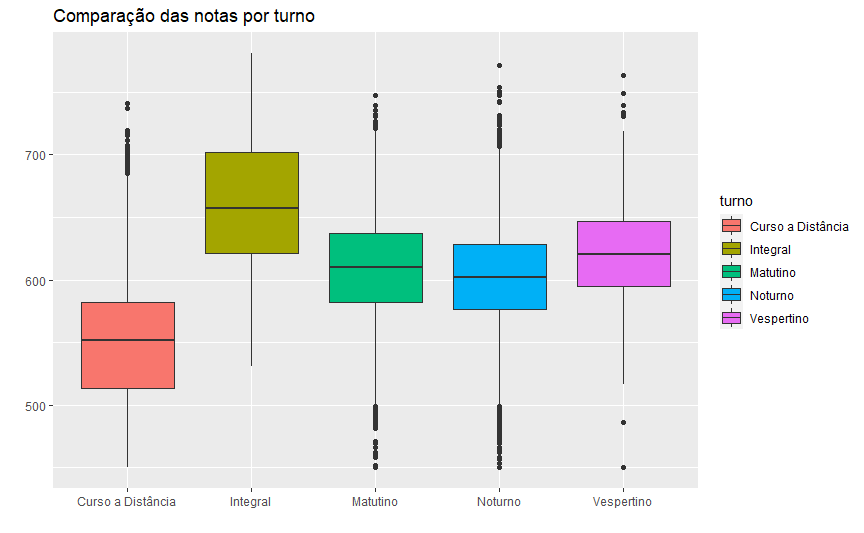

1. Pelo gráfico, qual dos turnos possui a maior mediana das notas? Explique.
2. Qual a média e a mediana do turno identificado no item anterior?
3. Qual dos cinco turnos possui menor homegeneidade na nota integral ampla?

**Questão 08.** Qual a posição ocupa o estado da Bahia, no que se refere à frequência absoluta da variável `uf_busca`, disposta de forma decrescente?

**Questão 09.** Quantos cursos foram identificados, distintamente, na variável `nome`?

**Questão 10.** Apenas observando o gráfico abaixo, o que você pode concluir com respeito aos cursos exibidos, comparativamente? (cite, pelo menos, duas características gráficas).

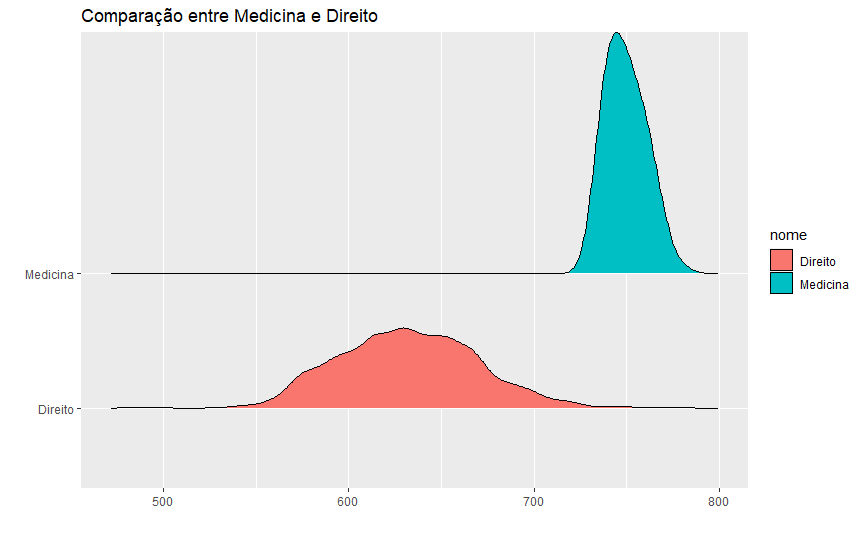

## Dicas

- Organize seu ambiente de trabalho com um Projeto em R;
- Carrege os conjuntos de dados separadamente, pois se a memória do seu computador for pequena, pode causar lentidão;
  - Por exemplo, leia o conjunto de dados `contracheque.csv`, resolva as questões referente a esse tópico e depois, no console, digite `rm(list = ls())`. Aí é só carregar um outro conjunto de dados.
  - O comando `rm(list = ls())` limpa a memória armazenada até aquele momento pelas variáveis no `R`.

[figure not shown]